# Pràctica 2 - Neteja i anàlisis de les dades

##### Test de dues mostres de Pokemons de tipus Psychic

**Segons alçada:**

H0: µbaix = µalt H1: µbaix < µalt

Utilitzarem un test de dues mostres independents. Pel teorema del límit central, assumim normalitat.

```r
var.test(pokedexAnalysis.Psychic$total_points[pokedexAnalysis.Psychic$Fheight_m=="baix"], pokedexAnalysis.Psychic$total_points[pokedexAnalysis.Psychic$Fheight_m=="alt"], alternative = "less")
```

```
##
##  F test to compare two variances
##
## data:  pokedexAnalysis.Psychic$total_points[pokedexAnalysis.Psychic$Fheight_m ==  and pokedexAnalysis.Psychic$total_points[pokedexAnalysis.Psychic$Fheight_m ==     "baix"] and     "alt"]
## F = 1.485, num df = 46, denom df = 28, p-value = 0.8664
## alternative hypothesis: true ratio of variances is less than 1
## 95 percent confidence interval:
##  0.000000 2.556441
## sample estimates:
## ratio of variances
##           1.485033
```

El resultat del test F és que podem assumir igualtat de variàncies. Per tant, apliquem test t de dues mostres independents per a la diferència de mitjanes, variàncies desconegudes i iguals. El test és unilateral.

```r
t.test(total_points~Fheight_m,pokedexAnalysis.Psychic,var.equal=T, alternative="less")
```

```
##
##  Two Sample t-test
##
## data:  total_points by Fheight_m
## t = 7.1286, df = 74, p-value = 1
## alternative hypothesis: true difference in means is less than 0
## 95 percent confidence interval:
##      -Inf 226.6471
## sample estimates:
##  mean in group alt mean in group baix
##           598.9310           415.2128
```

#### 4.3.3 Fer una predicció de com les variables d’estidistica base, el pès i l’alçada influeixen amb la variable base_experience.

Aplicarem cinc model de regressió lineal múltiple que cadascún d’ells usaran diferents variables explicatives: attack, defense, sp_attack, sp-defense, hp, speed, Fheight-m i Fweight_kg.

Especificarem en el nivell base (en el relevel): per la variable Fheight_m, la categoria “alt”, i per la variable Fweight_kg la categoria “lleuger”.

```r
heightR <- relevel(pokedexAnalysis$Fheight_m, ref="alt" )

weightR <- relevel(pokedexAnalysis$Fweight_kg, ref="lleuger")

pokedexAnalysis$heightR <- heightR
pokedexAnalysis$weightR <- weightR


mod1 <- lm(base_experience~attack+defense+sp_attack+sp_defense+hp+speed+heightR+weightR, pokedexAnalysis )

mod2 <- lm(base_experience~attack+defense+sp_attack+sp_defense+hp+speed, pokedexAnalysis )

mod3 <- lm(base_experience~attack+defense+hp+speed+heightR+weightR, pokedexAnalysis )

mod4 <- lm(base_experience~attack+sp_attack+hp+speed+heightR+weightR, pokedexAnalysis )

mod5 <- lm(base_experience~attack+defense+sp_attack+sp_defense+heightR+weightR, pokedexAnalysis )
```

Per els anteriors models de regressió lineal múltiple obtinguts, podem utilitzar el coeficient de determinació per mesurar la bondat d’ajust i quedar-nos amb el model que tingui millor coeficient.

```r
#summary(mod1)
tabla.coeficientes <- matrix(c(1, summary(mod1)$r.squared, 2, summary(mod2)$r.squared, 3,   summary(mod3)$r.squared, 4, summary(mod4)$r.squared, 5, summary(mod5)$r.squared), ncol = 2, byrow = TRUE)
colnames(tabla.coeficientes) <- c("Model", "R^2")
tabla.coeficientes
```

```
##      Model       R^2
## [1,]     1 0.8806787
## [2,]     2 0.8776792
## [3,]     3 0.7898483
## [4,]     4 0.7837578
## [5,]     5 0.7882521
```

El primer model és el més convenient ja que te un major coeficient de determinació. Ara utilitzarem aquest model per fer prediccions amb diferents valors:

```r
F0<-data.frame( attack=130, defense=80, sp_attack=110, sp_defense=90, hp=75,speed=20,heightR="alt",weightR="pesat")
predict(mod1, F0)
```

```
##        1
## 185.7625
```

```r
F1<-data.frame( attack=60, defense=57, sp_attack=101, sp_defense=86, hp=100,speed=180,heightR="baix",weightR="pesat")
predict(mod1, F1)
```

```
##        1
## 246.5225
```

```r
F2<-data.frame( attack=49, defense=49, sp_attack=65, sp_defense=65, hp=45,speed=45,heightR="baix",weightR="lleuger")
predict(mod1, F2)
```

```
##        1
## 79.39432
```

```r
F3<-data.frame( attack=130, defense=80, sp_attack=110, sp_defense=90, hp=75,speed=20,heightR="alt",weightR="lleuger")
predict(mod1, F3)
```

```
##        1
## 196.4184
```

```r
##valors minims
F4<-data.frame( attack=5, defense=5, sp_attack=10, sp_defense=20, hp=1,speed=5,heightR="baix",weightR="lleuger")
predict(mod1, F4)
```

```
##         1
## -89.07218
```

```r
##valors mitjans
F5<-data.frame( attack=80.12, defense=74.48, sp_attack=71.73, sp_defense=72.13, hp=69.58,speed=68.53,heightR="baix",weightR="lleuger")
predict(mod1, F5)
```

```
##        1
## 151.8014
```

```r
##valors màxims
F6<-data.frame( attack=190, defense=250, sp_attack=194, sp_defense=250, hp=255,speed=180,heightR="baix",weightR="lleuger")
predict(mod1, F6)
```

```
##        1
## 721.0123
```

En les anteriors prediccions del model, es pot observar el base_experience. La variable Hp, es una de les variables que té més pes alhora que tingui més base_experience. S’ha fet un anàlisi per veure el comportament segons els valors mínims, mitjans i màxims, i s’ha observat que amb valors mínims fa una predicció d’un Pokémon inexistent, ja que no hi ha cap Pokémon amb una base_experience negativa. Quan és valors mitjans, s’adapta bastant amb la mitjana de base_experience que és de 153.8. I quan es tracta amb valors màxims, deixa una base_experience, més elevada que la que podem trobar en ella.

## 5. Representació dels resultats a partir de taules i gràfiques.

Com s’ha pogut veure, durant l’anàlisi s’han realitzat taules i gràfiques per fer un anàlisi visual de les dades.

A continuació mostrem les correlacions realitzades mitjançant gràfics:

#### Correlació dels Pokemons en general

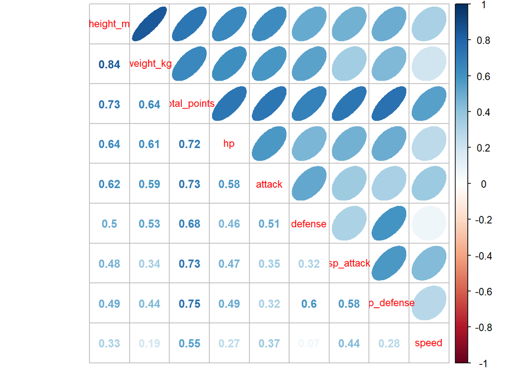

```r
corrplot.mixed(corr.general,upper="ellipse",number.cex=.9,tl.cex=.8)
```

En el gràfic, es pot observar d’una manera ràpida, que no hi ha correlacions negatives. Quan és un el·lipse més pronunciat, té un color blau més fosc que indica més correlació. Quan més arrodonit i color més claret, menys hi ha correlació positiva.

Es pot observar que la correlació més forta quan s’estudien els Pokemons en general, és el seu pès i la seva alçada.

#### Correlació dels Pokemons Legendaris

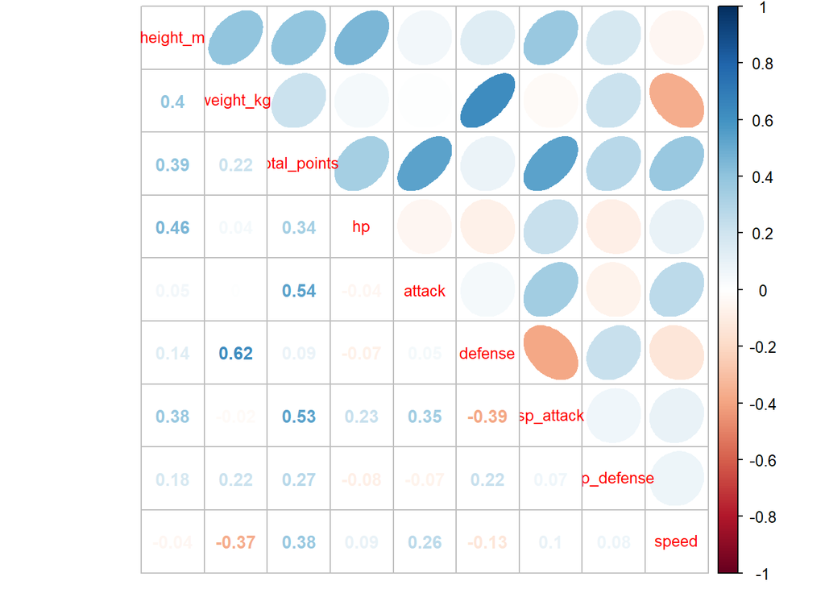

```r
corrplot.mixed(corr.legendary,upper="ellipse",number.cex=.9,tl.cex=.8)
```

En el gràfic, es pot observar d’una manera ràpida, que hi ha poques correlacions negatives. Quan és un el·lipse més pronunciat, té un color blau més fosc que indica més correlació. Quan més arrodonit i color més claret, menys hi ha correlació positiva. Les figures transparents ens indiquen que la correlació està pels voltants del 0. I les figueres de color ataronjat ens indiquen que hi ha un mica de correlació negativa.

Es pot observar que la correlació més forta quan s’estudien els Pokemons Llegendaris, és el seu pès i la seva defensa. I més negativa és defense i sp_attack, que vol dir que quan una d’elles puja l’altre disminueix.

#### Correlació dels Pokemons Sub Legendaris

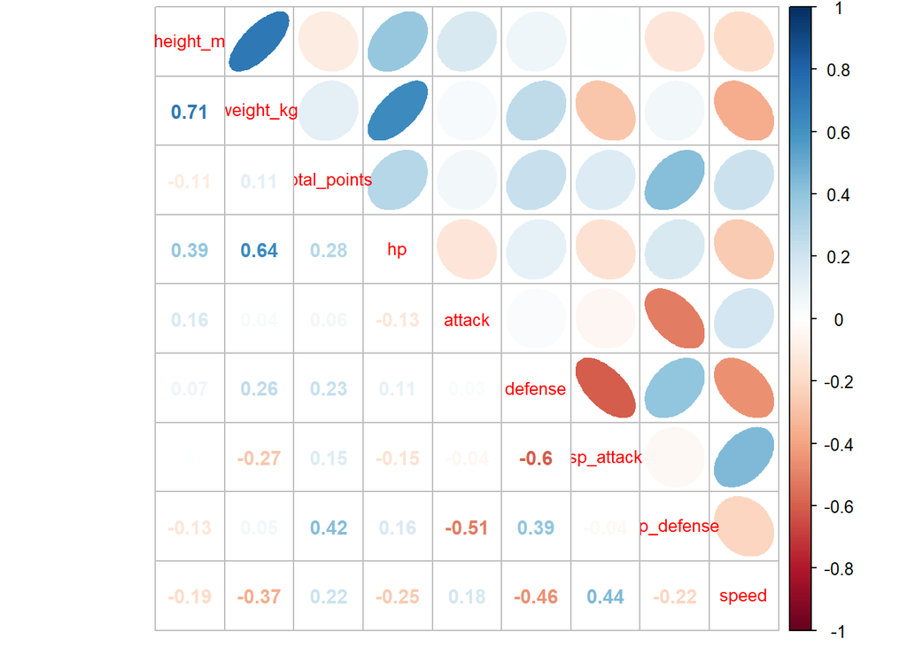

```r
corrplot.mixed(corr.sublegendary,upper="ellipse",number.cex=.9,tl.cex=.8)
```

En el gràfic, es pot observar d’una manera ràpida, que hi ha bastantes correlacions negatives. Quan és un el·lipse més pronunciat, té un color blau més fosc que indica més correlació. Quan més arrodonit i color més claret, menys hi ha correlació positiva. Les figures transparents ens indiquen que la correlació està pels voltants del 0. I les figueres de color ataronjat ens indiquen que hi ha un mica de correlació negativa, i les figueres de color més vermellós, ens indiquen que hi ha molta correlació negativa.

Es pot observar que la correlació més forta quan s’estudien els Pokemons Sub Llegendaris, és el seu pes i la seva l’alçada, i més negativa és defense i sp_attack, que vol dir que quan una d’elles puja l’altre disminueix.

#### Correlació dels Pokemons de tipus Bug

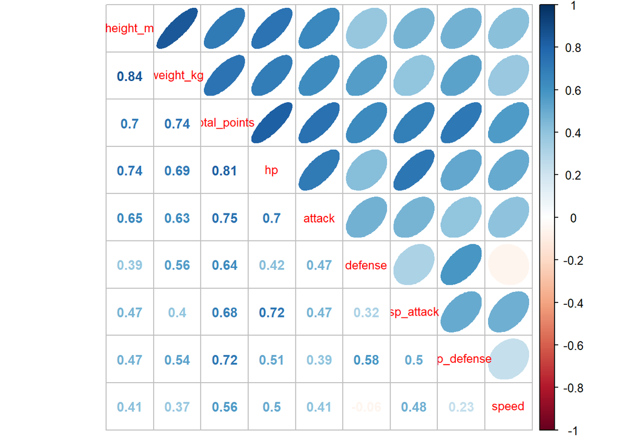

```r
corrplot.mixed(corr.bug,upper="ellipse",number.cex=.9,tl.cex=.8)
```

Es pot observar que la correlació més forta quan s’estudien els Pokemons de tipus bug, és el seu pès i la seva alçada.

#### Correlació dels Pokemons de tipus Dragon

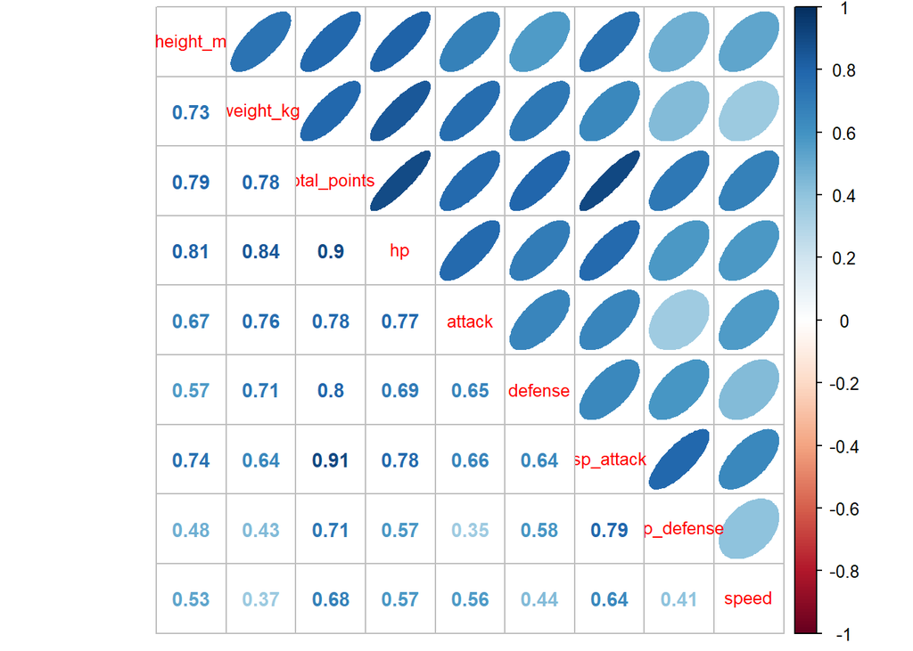

```r
corrplot.mixed(corr.dragon,upper="ellipse",number.cex=.9,tl.cex=.8)
```

En el gràfic, es pot observar d’una manera ràpida, que no hi ha correlacions negatives. Quan és un el·lipse més pronunciat, té un color blau més fosc que indica més correlació. Quan més arrodonit i color més claret, menys hi ha correlació positiva.

Es pot observar que la correlació més forta quan s’estudien els Pokemons de tipus dragon, és el seu total_points i la sp_attack.

#### Correlació dels Pokemons de tipus Poison

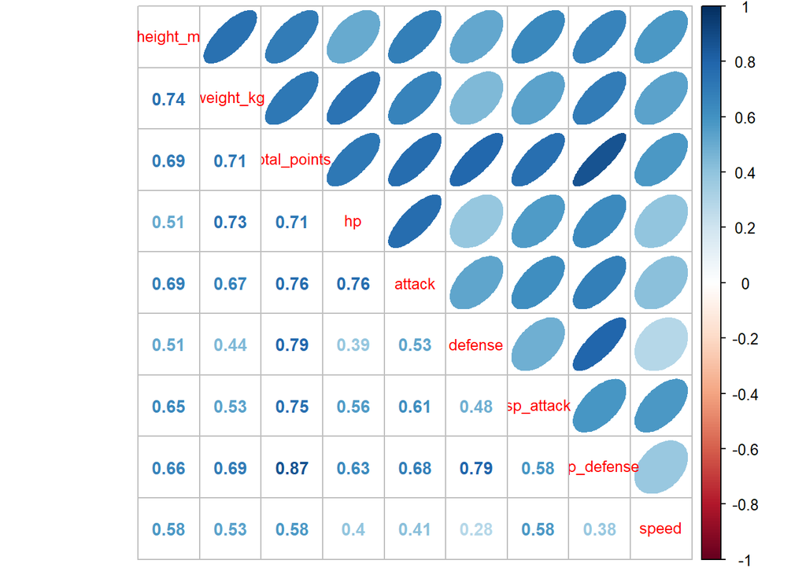

```r
corrplot.mixed(corr.poison,upper="ellipse",number.cex=.9,tl.cex=.8)
```

En el gràfic, es pot observar d’una manera ràpida, que no hi ha correlacions negatives. Quan és un el·lipse més pronunciat, té un color blau més fosc que indica més correlació. Quan més arrodonit i color més claret, menys hi ha correlació positiva.

Es pot observar que la correlació més forta quan s’estudien els Pokemons de tipus Poison, és el seu total_points i la sp_defense.

#### Correlació dels Pokemons de tipus Steel

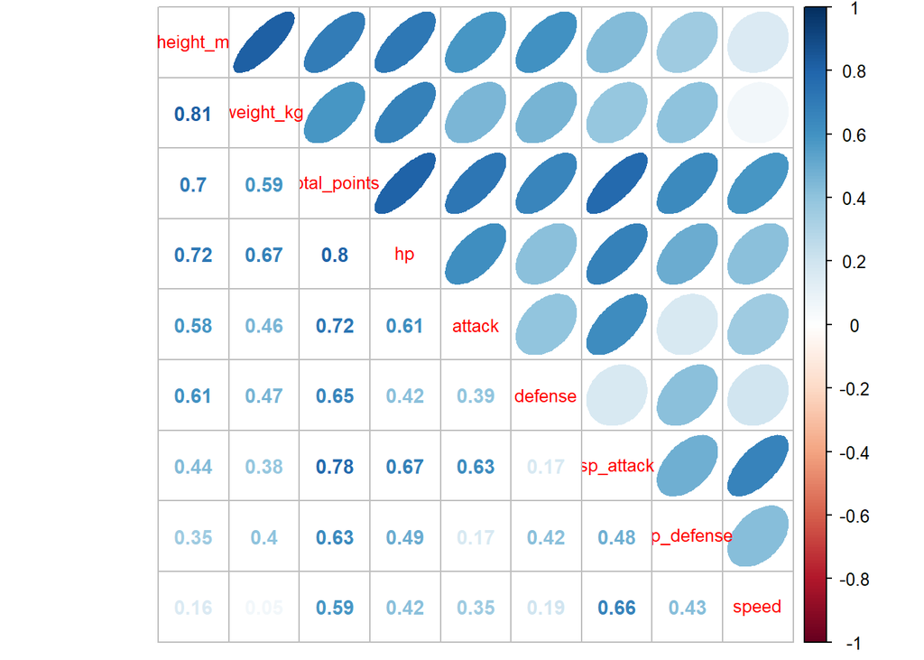

```r
corrplot.mixed(corr.steel,upper="ellipse",number.cex=.9,tl.cex=.8)
```

En el gràfic, es pot observar d’una manera ràpida, que no hi ha correlacions negatives. Quan és un el·lipse més pronunciat, té un color blau més fosc que indica més correlació. Quan més arrodonit i color més claret, menys hi ha correlació positiva.

Es pot observar que la correlació més forta quan s’estudien els Pokemons de tipus Steel, és el seu pès i la l’alçada.

#### Correlació dels Pokemons de tipus Psychic

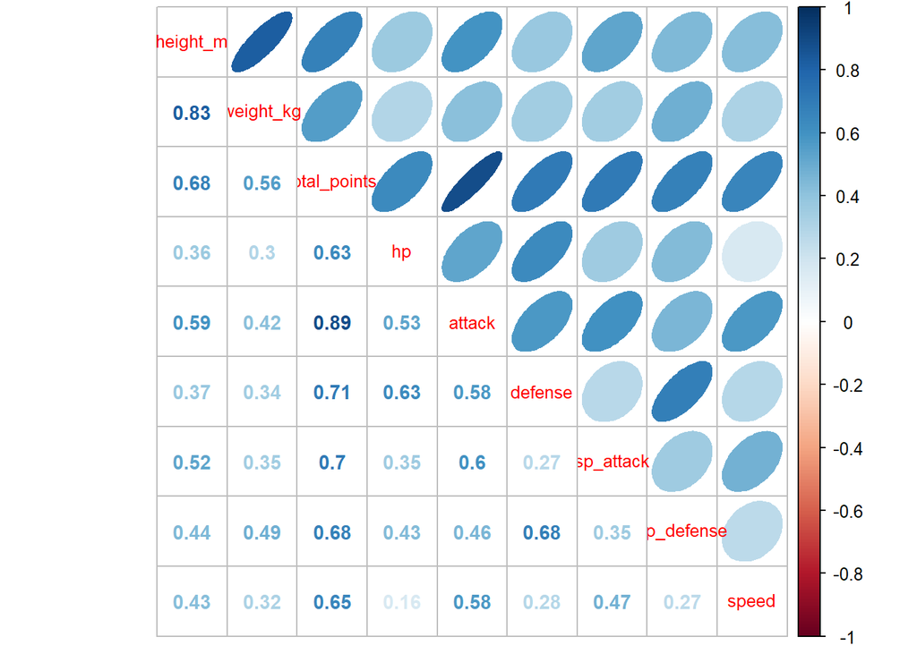

```r
corrplot.mixed(corr.psychic,upper="ellipse",number.cex=.9,tl.cex=.8)
```

En el gràfic, es pot observar d’una manera ràpida, que no hi ha correlacions negatives. Quan és un el·lipse més pronunciat, té un color blau més fosc que indica més correlació. Quan més arrodonit i color més claret, menys hi ha correlació positiva.

## 6. Resolució del problema. A partir dels resultats obtinguts, quines són les conclusions? Els resultats permeten respondre al problema?

Amb l’estudi realitzat, hem estudiat especialment variables del Pokémon com la seva alçada i el seu pès, juntament amb les variables d’estadístiques bàsiques: total de punts, HP, atac, defensa, velocitat, atac especial i desfensa especial i llavors de la informació d’entrenament: l’experiència base. Pensem que aquestes variables analitzades ens han destapat coneixaments que no ens esperàvem, com que els Pokémons menys estables són els Llegendaris i Sub llegendaris, hem pogut veure que les variables entre elles tenen poca relació. Creiem que això pot ser degut a que aquets Pokemons tenen unes característiques molt variades. Hem estudiat els tipus de Pokémon: bug, dragon, poison, psychic i steel, perquè amb l’estudi visual de la distribució del tipus amb el total de punts, són els que ens han cridat més l’atenció, els dragon, els més forts, els bug els més dèbils, els poison, els més destacats en els llegendàris, els psychic i amb els steels, els que tenen els quartils i els bigotis del boxplot, més proporcionats. Hem pogut concloure, en forma general, el pès i l’alçada dels pokemons es correlacionen molt bé, cosa que creiem que és força lògica ja que normalment quan es te més alçada també es te més pes. S’ha demostrat que els Pokemons de tipus dragon són els més forts, i tenen les variables d’estadístiques base més correlacionades. Els Sub llegendaris, els que tenen les variables d’estadístiques base amb correlacions més negatives. Els de tipus poison i steel són bastant iguals en correlació de les variables d’estadístiques base. I els de tipus bug, els més fluixets.

Referent a l’estudi de l’experiència base, es pot dir que el que influeix una mica més és l’hp, però en general totes les variables d’estadística base tenen més o menys un pes per donar el valor de l’experiència base. Ens ha sobtat que quan hem posat els mínims que hi ha a la base de dades, el valor ha estat negatiu.

Per tant, podem dir que hem pogut resoldre les inquietuds que teníem respecte els Pokemons més forts, els llegendaris i sub llegendaris. També hem pogut observar que cada tipologia de Pokemons, té alguna particularitat en especial respecte al total_points, cada ún d’ells es correlaciona amb més força amb una variable diferent. El de tipus Psychic és l’attack amb un 0.888, el de tipus Steel és l’HP amb un 0.804, el de tipus Poison és l’sp_defense amb un 0.866, el de tipus Dragon és sp_attack amb un 0.907, el de tipus Bug és HP amb un 0.813, els sub llegendaris és sp_defense amb un 0.42, els llegendaris és attack amb un 0.539 i els de tipus normal és sp_defense amb un 0.729.

## 7. Codi: Cal adjuntar el codi, preferiblement en R, amb el que s’ha realitzat la neteja, anàlisi i representació de les dades. Si ho preferiu, també podeu treballar en Python.

El codi R, està inclòs en aquest mateix informe.

## 8. Bibliografia

Donem gràcies a Mario Tormo Romero per Dataset de https://www.kaggle.com/mariotormo/complete-pokemon-dataset-updated-090420

- https://pokemon.fandom.com/es/wiki/Crianza_Pok%C3%A9mon
- https://es.wikipedia.org/wiki/Coeficiente_de_correlaci%C3%B3n_de_Spearman
- https://pokemon.fandom.com/es/wiki/Experiencia_base

## 9.Contribucions

- **Investigació prèvia:** David Navarro, Antoni Llussà
- **Redacció respostes:** David Navarro, Antoni Llussà
- **Desenvolupament codi:** David Navarro, Antoni Llussà